# A method to develop an informed sampling design and absence selection for invasive species

Recording and monitoring invasive species is one critical step in the efforts to manage biological invasions, and zith this purpose field sampling is often used in species distribution models to produce current and potential distribution maps. However, field sampling is supceptible to bias due to factors such as sampling effort, species detectability, environmental heterogeneity, species identification, among others. This is why, combining the knowledge on the ecology of the species with an informed sampling design (e.g. sampling locations and effort) is of paramount importance to accurately record species occurrences.

Furthermore, at the modelling stage, data on the locations where species is absent is key to accurately tune the distribution models. One key assumption is that species are at equilibrium with the environment, that is, the species has already occupied all the suitable habitat. That is not the case for invasive species where the distribution depends on the time since invasion and its rate of colonization and establishment, hence the importance of a careful selection of absences to avoid data in areas of suitable habitat not yet colonized by the invader (known as contigent absences) ([Lobo et al. 2010](http://onlinelibrary.wiley.com/doi/10.1111/j.1600-0587.2009.06039.x/abstract)).

In this tutorial, we will work with the `iSDM` R package, developed as part of the DIARS project, with the aim of providing tools to improve sampling design and absences selection using environmental factors derived from LiDAR data.

### The dataset

This tutorial is divided in two sections:

1. Performing an environmental systemic sampling design

2. Calculating the likelihood of absences in suitable areas

##### Environmental systemic sampling design

Lets start by installing and loading the libraries that we are going to be using in this tutorial.

```r
install.packages("devtools")
devtools::install_github("TarekHattab/iSDM")
library(iSDM)

library(raster)
```

And import the raster files with environmental variables of the study area:

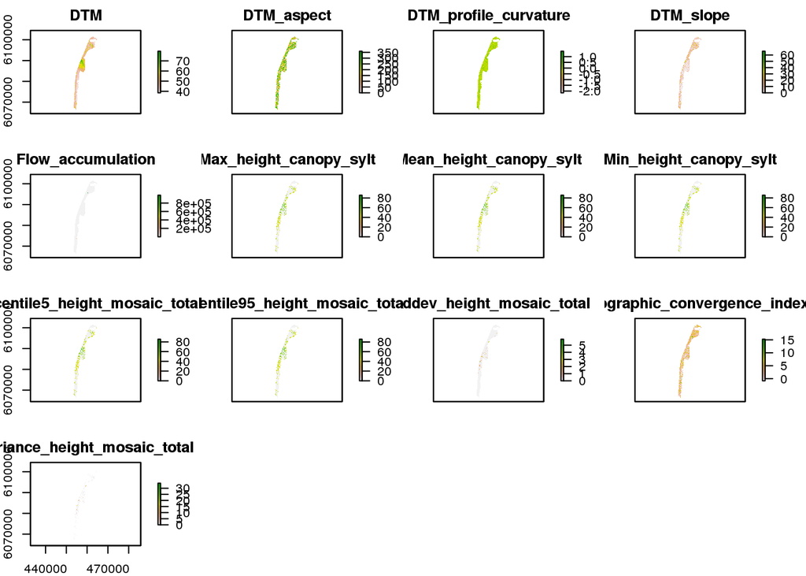

```r
setwd("/home/garzonc/Desktop/DIARS")
envData <- stack(list.files("./Rasters/", full.names = TRUE))
plot(envData)
```

After importing the raster layers you can use the function `EnvSysSample` to perform the environmental systemic sampling design. Before running the code is important to determine the number of sampling points needed (nExpect), the number of dimensions (maximum three) to be used in the ordination analysis, and the upper (upperLim) and lower (lowerLim) limits of the quantile probability (0 to 1). NOTE: Change the probabilities and the number of samples to explore the combination that results in a robust sampling design for the study area and the focal species.

```r
MySampling <- EnvSysSample(envData, nExpect = 50, plot = TRUE, saveShape = TRUE,
    lowerLim = 0.001, upperLim = 0.999, nf = 3)
```

```
## [1] "-----------------Optimization of the 3 D grid size---------------------"
##
## [1] "-----------------61 points found---------------------"
```

[interactive chart not shown]

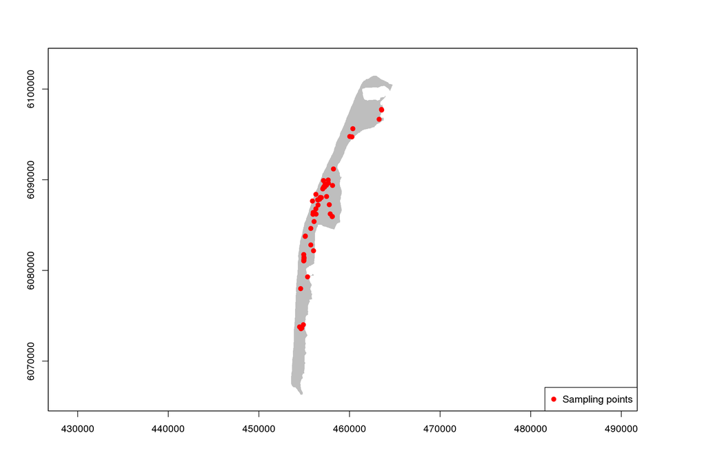

```r
plot(envData[[1]], legend = FALSE, col = "gray")  #Plot the first layer in the environmental variables stack
plot(MySampling[[1]], add = TRUE, col = 2, pch = 19)
legend(x = "bottomright", legend = "Sampling points", col = "red", pch = 19,
    cex = 1)
```

##### Calculating the likelihood of absences in suitable habitat

The function `likelihoodCA`, from the iSDM package, allows the calculation of the likelihood of detecting absences at suitables areas (known as contigent absences). The user must provide a table of species presences and absences collected from the field. If absence data is not available, the function can be used in previously generated pseudoabsences. The function is based on the idea that absence data environmentally close (within the suitable habitat) but geographically distant from presences are more likely to be contigent absences.

Lets start by installing and loading the libraries that will be using in this tutorial:

```r
library(raster)
library(sp)
library(colorRamps)
# install.packages('devtools') devtools::install_github('TarekHattab/iSDM')
library(iSDM)
library(rgrass7)

# dir.create('grassdata')

myGRASS <- "/usr/local/grass-7.0.4svn"
myGISDbase <- "/home/garzonc/Documents/grassData"
myLocation <- "DIARS"
myMapset <- "PERMANENT"

initGRASS(myGRASS, home = tempdir(), gisDbase = myGISDbase, location = myLocation,
    mapset = myMapset, override = TRUE)
```

```
## gisdbase    /home/garzonc/Documents/grassData
## location    DIARS
## mapset      PERMANENT
## rows        31
## columns     33
## north       6080248
## south       6079942
## west        463974.6
## east        464307.6
## nsres       9.870968
## ewres       10.09091
## projection  +proj=utm +no_defs +zone=32 +a=6378137 +rf=298.257223563
## +towgs84=0.000,0.000,0.000 +to_meter=1
```

```r
execGRASS("g.proj", flags = c("c"), parameters = list(epsg = 32632))
```

```
## Projection information updated
```

```r
execGRASS("g.region", parameters = list(n = "6080248.2", s = "6079942.2", e = "464307.5969",
    w = "463974.5969", res = "10"))
```

Import the raster files with environmental variables of the study area, and the presence/absence dataset. The presence/absence dataset in this case correspond to the species coverage per plot data contained in the vector `cal_points`:

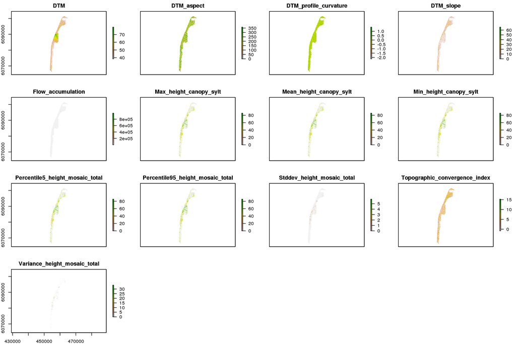

```r
setwd("/home/garzonc/Desktop/DIARS")
envData <- stack(list.files("./Rasters/", full.names = TRUE))
plot(envData)
```

```r
execGRASS("v.in.ogr", flags = c("overwrite", "quiet"), parameters = list(input = "/home/garzonc/Desktop/DIARS/cal_points.shp",
    output = "cal_points"))
```

```
## WARNING: Vector map <cal_points> already exists and will be overwritten
```

```r
pointdata <- readVECT("cal_points")
```

```
## Exporting 90 features...
##    5%  11%  17%  23%  30%  36%  42%  48%  54%  60%  66%  72%  78%  84%  90%  96% 100%
## v.out.ogr complete. 90 features (Point type) written to <cal_points>
## (SQLite format).
```

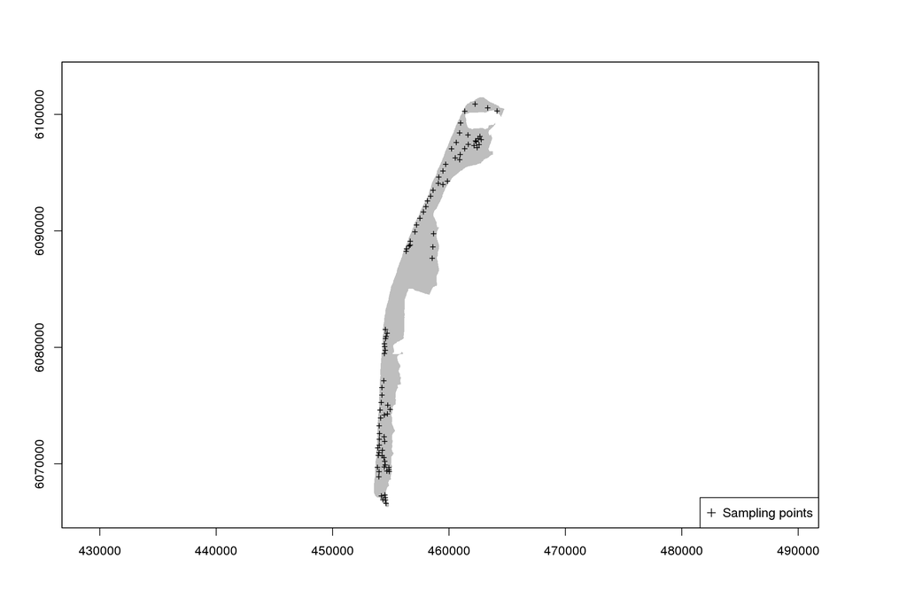

```r
presence <- subset(pointdata@data, cam_cover > 0)
absence <- subset(pointdata@data, cam_cover <= 0)
B <- c(rep(1, nrow(presence)), rep(0, nrow(absence)))
occData <- as.data.frame(cbind(rbind(presence, absence), B, pointdata@coords))
occData <- occData[, -c(1:8)]
coordinates(occData) <- ~coords.x1 + coords.x2
proj4string(occData) <- proj4string(envData)
plot(envData[[1]], legend = FALSE, col = "gray")
plot(occData, add = TRUE, pch = 3, cex = 0.6)
legend(x = "bottomright", legend = "Sampling points", col = "black", pch = 3,
    cex = 1)
```

Now calculate the likelihood of detecting contigent absences, based on three environmental layers (1,5,6) and display the results:

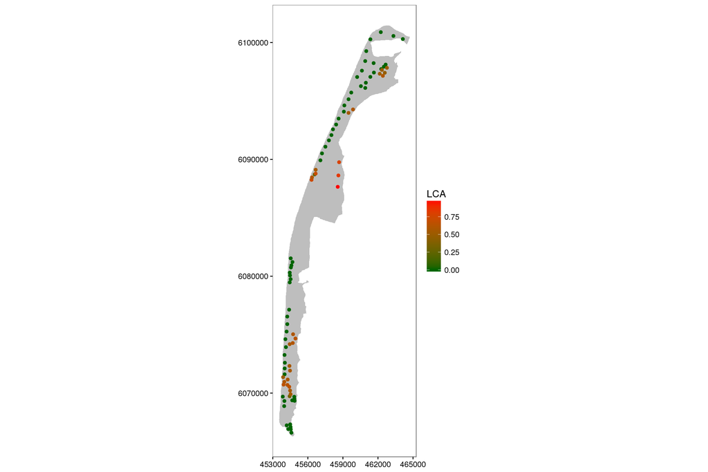

```r
library(iSDM)
likelihood <- likelihoodCA(occData = occData, envData = envData[[c(1, 5, 6)]],
    longlat = FALSE)

likelihood1 <- as.data.frame(cbind(likelihood@coords, likelihood@data[, "LCA"]))
colnames(likelihood1) <- c("x", "y", "LCA")

envMap <- rasterToPoints(envData[[1]])
Map <- data.frame(envMap)
colnames(Map) <- c("X", "Y", "MAP")

library(ggplot2)
ggplot(data = Map, aes(y = Y, x = X)) + geom_raster(fill = "gray") + geom_point(data = likelihood1,
    aes(x = x, y = y, color = LCA)) + theme_bw() + coord_equal() + scale_color_gradient("LCA",
    low = "dark green", high = "red") + theme(axis.title.x = element_blank(),
    axis.title.y = element_blank(), panel.grid.major = element_blank(), panel.grid.minor = element_blank(),
    legend.position = "right", legend.key = element_blank())
```

The resulting table contains a column with likelihood of contigent absences.

More information about the iSDM package and the functions presented in this tutorial can be found [HERE](https://github.com/TarekHattab/iSDM)

###### Back to the top

**Authors**: Tarek Hattab, Carol Garzon-Lopez, Duccio Rocchini & Jonathan Lenoir

**Date**: 2016-05-20